# Machine Learning HW 4

## Summary of Project

Using devices such as Jawbone Up, Nike FuelBand, and Fitbit it is now possible to collect a large amount of data about personal activity relatively inexpensively. These type of devices are part of the quantified self movement - a group of enthusiasts who take measurements about themselves regularly to improve their health, to find patterns in their behavior, or because they are tech geeks. One thing that people regularly do is quantify how much of a particular activity they do, but they rarely quantify how well they do it. In this project, your goal will be to use data from accelerometers on the belt, forearm, arm, and dumbell of 6 participants. They were asked to perform barbell lifts correctly and incorrectly in 5 different ways. More information is available from the website here: http://groupware.les.inf.puc-rio.br/har (see the section on the Weight Lifting Exercise Dataset).

## Data Set

The training data for this project are available here: https://d396qusza40orc.cloudfront.net/predmachlearn/pml-training.csv

The test data are available here: https://d396qusza40orc.cloudfront.net/predmachlearn/pml-testing.csv

## Building the Model

Reproduceability As with all reproducible result, set the seed, in my case set to 4172017.

The model was built: The ‘classe’ variable of the dataset contained in the last column, there are 5 factor variables witht eh following defintiion:

classe A = Exactly according to the specification classe B = Throwing the elbows to the front classe C = Lifting the dumbbell only halfway classe D = Lowering the dumbbell only halfway classe E = Throwing the hips to the front (Class E)

## load data

Load and cleanse the data

```r
trainset <- read.csv(".\\data\\pml-training.csv", na.strings=c("NA","#DIV/0!",""))
testset <- read.csv(".\\data\\pml-testing.csv", na.strings=c("NA","#DIV/0!",""))

## remove unnecessary columns for the model
trainset   <-trainset[,-c(1:7)]
testset <-testset[,-c(1:7)]

## Remove all missing values
trainset<-trainset[,colSums(is.na(trainset)) == 0]
testset <-testset [,colSums(is.na(testset)) == 0]

## use 80% to train model and 20% for testing model from the train set
set.seed(4172017)
inTrain <- createDataPartition(y=trainset$classe, p=0.8, list=FALSE)

Training <- trainset[inTrain, ];
Testing  <- trainset[-inTrain, ]

dim(Training);
```

```
## [1] 15699    53
```

```r
dim(Testing)
```

```
## [1] 3923   53
```

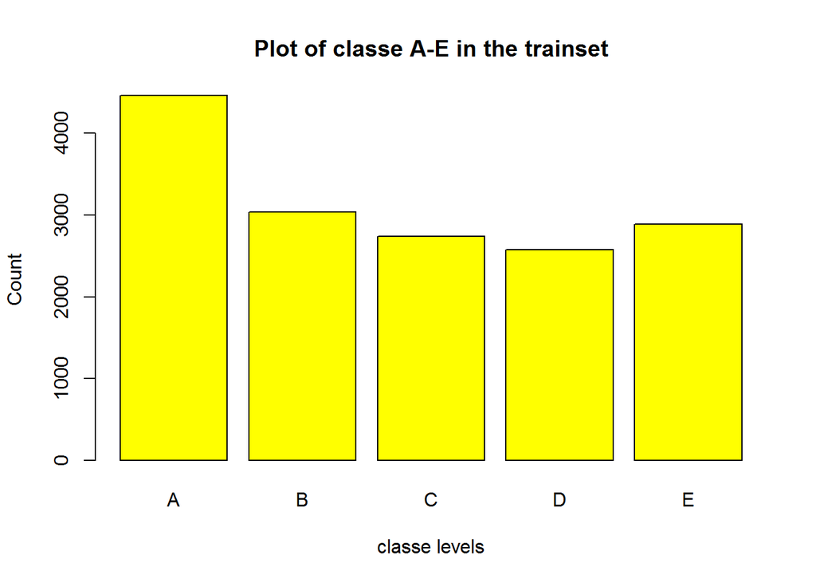

```r
## Plot Classe Levels
plot(Training$classe, col="yellow", main="Plot of classe A-E in the trainset", xlab="classe levels", ylab="Count")
```

## Try Classification Tree first

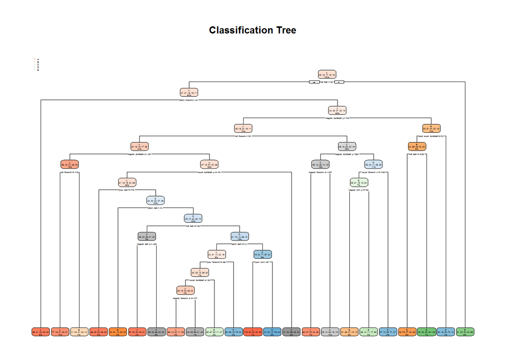

```
## Confusion Matrix and Statistics
##
##           Reference
## Prediction    A    B    C    D    E
##          A 1024  114   11   40    9
##          B   35  406   70   55   57
##          C   23  122  538  116   85
##          D   15   55   45  383   45
##          E   19   62   20   49  525
##
## Overall Statistics
##
##                Accuracy : 0.7331
##                  95% CI : (0.719, 0.7469)
##     No Information Rate : 0.2845
##     P-Value [Acc > NIR] : < 2.2e-16
##
##                   Kappa : 0.6617
##  Mcnemar's Test P-Value : < 2.2e-16
##
## Statistics by Class:
##
##                      Class: A Class: B Class: C Class: D Class: E
## Sensitivity            0.9176   0.5349   0.7865  0.59565   0.7282
## Specificity            0.9380   0.9314   0.8932  0.95122   0.9532
## Pos Pred Value         0.8548   0.6517   0.6086  0.70534   0.7778
## Neg Pred Value         0.9662   0.8930   0.9520  0.92308   0.9397
## Prevalence             0.2845   0.1935   0.1744  0.16391   0.1838
## Detection Rate         0.2610   0.1035   0.1371  0.09763   0.1338
## Detection Prevalence   0.3054   0.1588   0.2253  0.13841   0.1721
## Balanced Accuracy      0.9278   0.7332   0.8399  0.77343   0.8407
```

## Try Random Forest second

```
## Confusion Matrix and Statistics
##
##           Reference
## Prediction    A    B    C    D    E
##          A 1116    0    0    0    0
##          B    0  759    0    0    0
##          C    0    0  681    5    0
##          D    0    0    3  638    0
##          E    0    0    0    0  721
##
## Overall Statistics
##
##                Accuracy : 0.998
##                  95% CI : (0.996, 0.9991)
##     No Information Rate : 0.2845
##     P-Value [Acc > NIR] : < 2.2e-16
##
##                   Kappa : 0.9974
##  Mcnemar's Test P-Value : NA
##
## Statistics by Class:
##
##                      Class: A Class: B Class: C Class: D Class: E
## Sensitivity            1.0000   1.0000   0.9956   0.9922   1.0000
## Specificity            1.0000   1.0000   0.9985   0.9991   1.0000
## Pos Pred Value         1.0000   1.0000   0.9927   0.9953   1.0000
## Neg Pred Value         1.0000   1.0000   0.9991   0.9985   1.0000
## Prevalence             0.2845   0.1935   0.1744   0.1639   0.1838
## Detection Rate         0.2845   0.1935   0.1736   0.1626   0.1838
## Detection Prevalence   0.2845   0.1935   0.1749   0.1634   0.1838
## Balanced Accuracy      1.0000   1.0000   0.9970   0.9957   1.0000
```

## Conclusion

The Random Forest provided a better accuracy than the Classification Tree. Now apply the RF model to the actual test set

## Using Random Forest on the Test set

```
##  1  2  3  4  5  6  7  8  9 10 11 12 13 14 15 16 17 18 19 20
##  B  A  B  A  A  E  D  B  A  A  B  C  B  A  E  E  A  B  B  B
## Levels: A B C D E
```